# Techniki wizualizacji danych

### Praca domowa 5

#### Autor: Patryk Wołosz

W ramach tej pracy domowej przeprowadziłem dwa eksperymenty. Polegały one na sprawdzeniu czy niepoprawnie wykonane wykresy wprowadzają odbiorców w błąd - do każdego z wykresów były 3 pytania, na które odpowiadali ankietowani. 25 osób wzięło w ankiecie.

## Eksperyment 1

Podany był wykres widoczny poniżej. Na tym wykresie skala celowo nie zaczyna się od zera oraz dodany został element rozpraszający uwagę - wartość reprezentowana jako kolor.

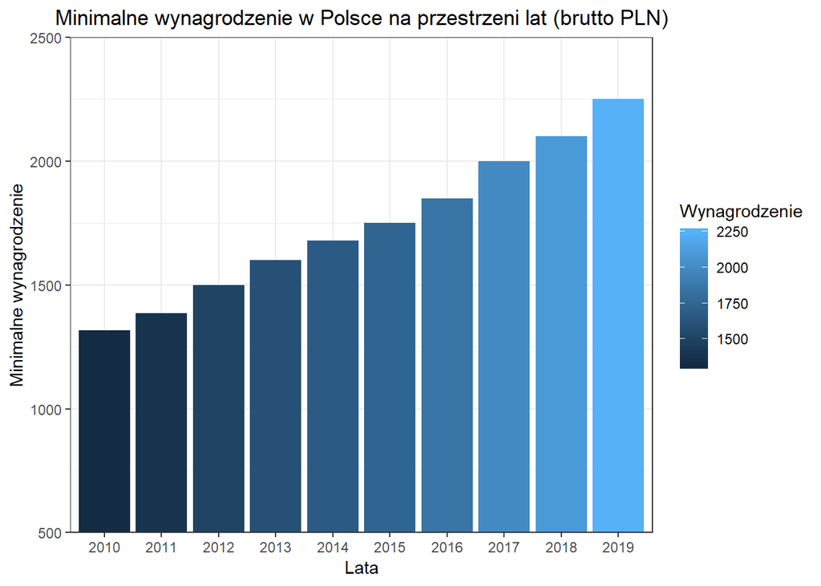

#### Pytanie 1 - Czy podane zdanie jest prawdziwe: “płaca minimalna zwiększyła się dwukrotnie od 2010 do 2019 roku”?

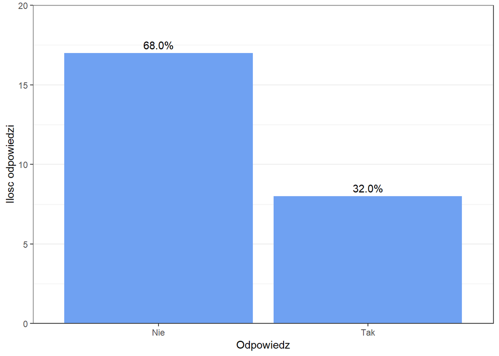

#### Pytanie 2 - Czy podane zdanie jest prawdziwe: “płaca minimalna w 2019 roku będzie wynosić około 2250 zł netto”?

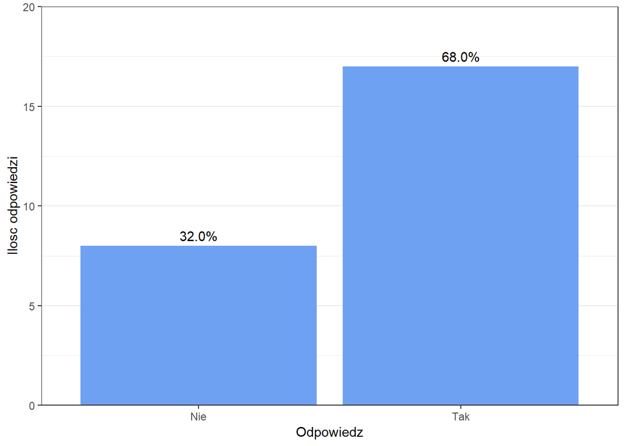

#### Pytanie 3 - Pierwsza rzecz, na którą zwróciłeś/aś uwagę to?

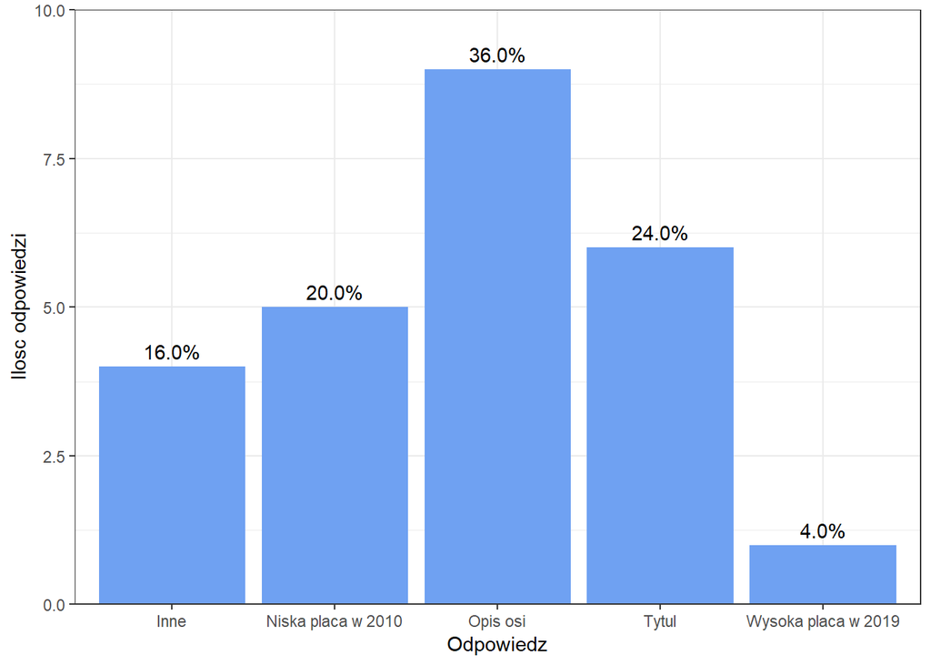

W przypadku tego wykresu niewiele osób nie zauważyło, że skala nie zaczyna się od zera (8 osób). Ciekawą obserwacją jest fakt, że aż 17 osób źle odpowiedziało na pytanie o płacę netto w 2019 roku, mimo, że informacja o tym, że są to kwoty brutto była w tytule (wszystkie osoby, które zadeklarowały, że pierwsza rzecz na którą zwróciły uwagę to tytuł źle odpowiedziały na to pytanie). Co do rozposzenia uwagi (pytanie 3) to widać, że ciemniejszy kolor (płaca najniższa) przykuł uwagę większej liczby osób niż jasny kolor dla najwyższej kwoty.

## Eksperyment 2

Widoczne były dwa wykresy podane poniżej, celem było sprawdzenie jak bardzo wykres kołowy 3D może przekłamywać dane.

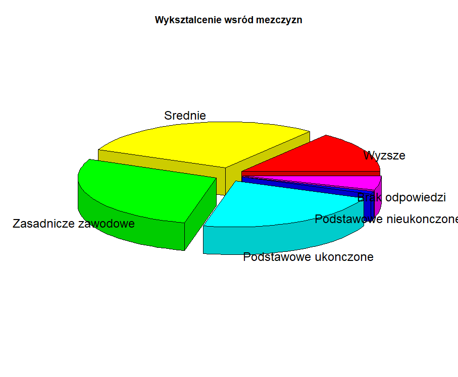

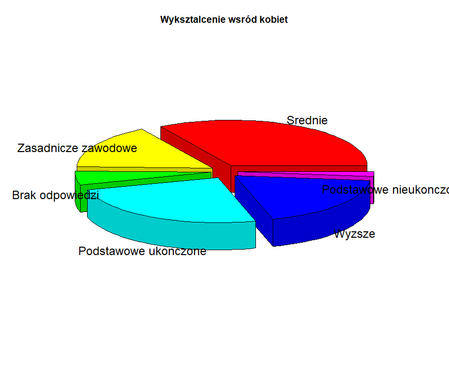

#### Pytanie 1 - Czy podane zdanie jest prawdziwe: “taki sam procent kobiet i mężczyzn posiada średnie wykształcenie”?

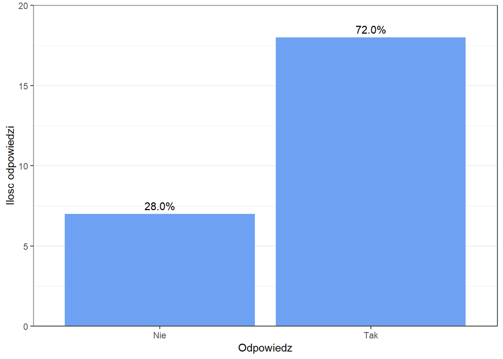

#### Pytanie 2 - Czy podane zdanie jest prawdziwe: “1/3 mężczyzn posiada średnie wykształcenie”?

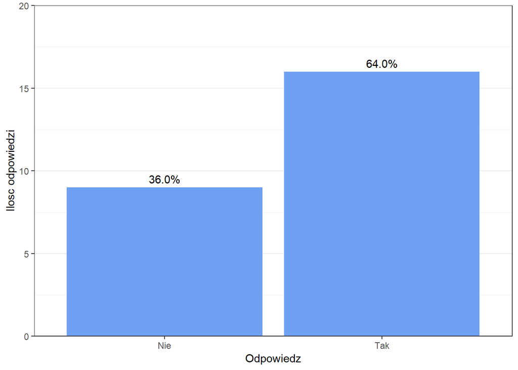

#### Pytanie 3 - Czy podane zdanie jest prawdziwe: “25% kobiet posiada wykształcenie podstawowe ukończone”?

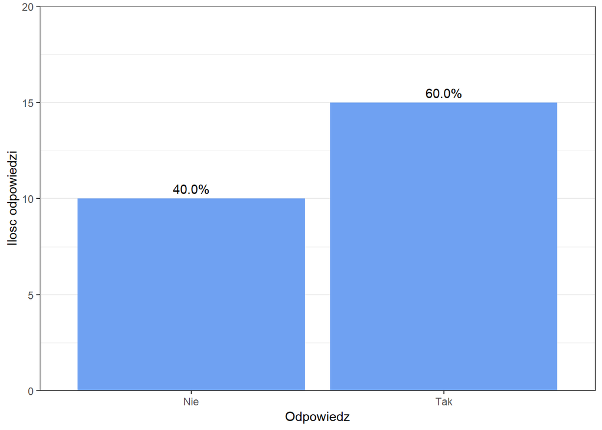

Właściwe rozkłady prezentują się następująco:

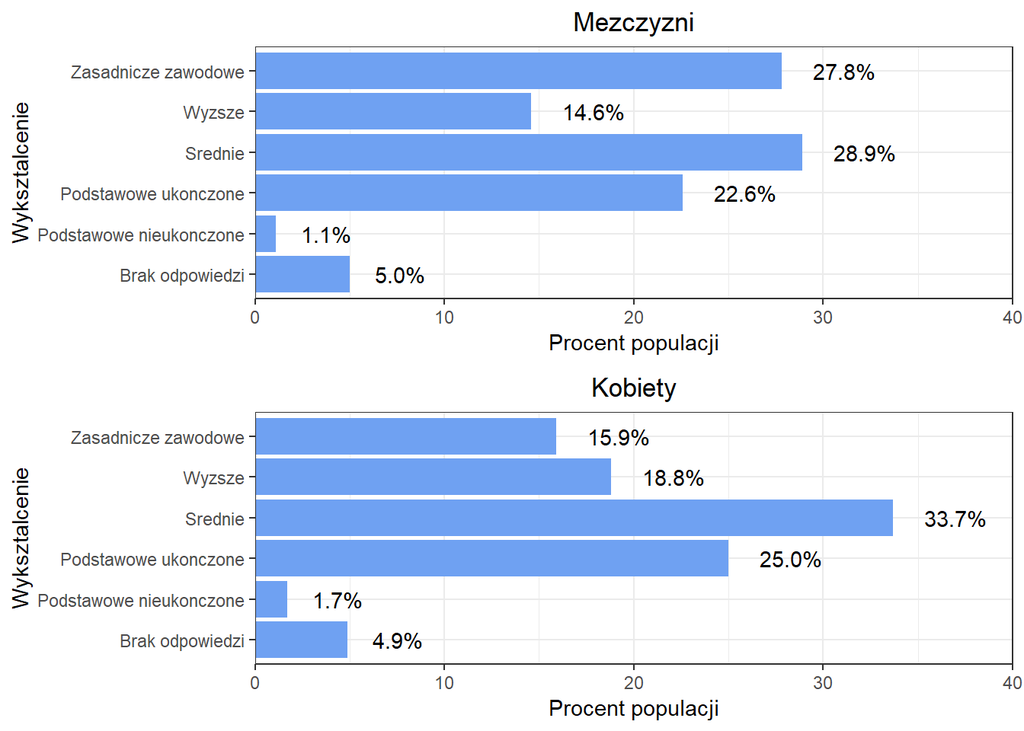